# Sortie plongée La Londe Les Maures

Du 28 octobre au 4 novembre 2023  
*Carole, tu veux que je te crame tes petits poils ?* — Grom, 31 octobre 2023

Auteur

Amitié Pictave

Dernière Mise à jour

dimanche 5 novembre 2023

## Plongeurs présents

Membres : Benoît, Carole, Jérôme, Nathalie, Pierre, Thomas  
Invités : Béatrice, Yannick

## Les plongées

Table 1: Récapitulatif des plongées effectuées

| Date | Quand | Site | Benoît | Carole | Jérôme | Nathalie | Pierre | Thomas | Béatrice | Yannick | Total |
| --- | --- | --- | --- | --- | --- | --- | --- | --- | --- | --- | --- |
| 29 10 2023 | am | Le Grec | 1 | 1 | 1 | 1 | 1 | 1 | 0 | 1 | 7 |
| 29 10 2023 | pm | Le Spahis | 1 | 1 | 0 | 0 | 1 | 1 | 0 | 1 | 5 |
| 30 10 2023 | am | Le Donator | 1 | 1 | 1 | 1 | 1 | 1 | 0 | 1 | 7 |
| 01 11 2023 | am | Le Ville de Grasse / Le Heinkel 111 | 1 | 1 | 1 | 1 | 1 | 1 | 0 | 1 | 7 |
| 01 11 2023 | pm | La Gabinière | 1 | 1 | 1 | 1 | 1 | 1 | 0 | 0 | 6 |
| Total | - | - | 5 | 5 | 4 | 4 | 5 | 5 | 0 | 4 | 32 |

Au total, 32 plongées ont été effectuées.

## Les dépenses “plongée”

Les dépenses entrant dans le calcul du coût des plongées sont détaillés dans le tableau ci-dessous.

Table 2: Dépenses engagées par les membres de l’AP

| Qui | Essence bateau | Essence compresseurs | Port | Gaz | Divers | Total |
| --- | --- | --- | --- | --- | --- | --- |
| Benoît | 246.74€ | 0.00€ | 0€ | 0€ | 0.00€ | 246.74€ |
| Carole | 0.00€ | 0.00€ | 0€ | 0€ | 0.00€ | 0.00€ |
| Jérôme | 211.36€ | 0.00€ | 163€ | 0€ | 0.00€ | 374.36€ |
| Nathalie | 0.00€ | 0.00€ | 24€ | 0€ | 0.00€ | 24.00€ |
| Pierre | 44.23€ | 44.22€ | 0€ | 0€ | 0.00€ | 88.45€ |
| Thomas | 0.00€ | 0.00€ | 0€ | 0€ | 19.90€ | 19.90€ |
| Total | 502.33€ | 44.22€ | 187€ | 0€ | 19.90€ | 753.45€ |

Ici, les dépenses de la rubrique “divers” concernent l’achat d’un nouveau cadenas pour la remorque.

## Coût des plongées

Le coût d’une plongée est calculé en divisant la somme des dépenses effectuées durant le séjour (ici, 753.45€) par le nombre total de plongées effectuées durant le séjour (ici, 32 plongées). Pour cette sortie, le coût d’une plongée pour les membres de l’AP est de 23.55€. Toutefois, afin d’anticiper sur la révision annuelle du moteur, nous avons décidé de majorer chaque plongée de 3€. Ainsi, **pour les membres, la plongée coûte 26.55€**.

Pour les invités, le prix de la plongée est fixé à 27€ si la plongée des membres coûte moins cher. Sinon, tout le monde paie le même prix. La même majoration de 3€ est appliquée pour les invités, soit un prix de 30€ par plongée.

Au total, pour les plongées uniquement, chaque plongeur doit les sommes suivantes à l’AP :

Table 3: Montants dûs pour la plongée

| Benoît | Carole | Jérôme | Nathalie | Pierre | Thomas | Béatrice | Yannick |
| --- | --- | --- | --- | --- | --- | --- | --- |
| 132.75€ | 132.75€ | 106.20€ | 106.20€ | 132.75€ | 132.75€ | 0€ | 120€ |

## Les dépenses “hors plongée”

Pour cette sortie, les dépenses n’entrant pas dans le prix des plongées et la liste des payeurs sont présentés dans le tableau Table 4. Pour chaque plongeur (et sa famille), les nombres de nuitées et de repas pris au cours du séjours sont indiqués dans le tableau Table 5 :

Table 4: Dépenses hors plongées engagées par les participants à la sortie

| Qui | Logement | Nourriture | Carburant | Peages | Navette | Divers | Total |
| --- | --- | --- | --- | --- | --- | --- | --- |
| Benoît | 0.00€ | 144.85€ | 132.24€ | 70.90€ | 0€ | 0€ | 347.99€ |
| Carole | 0.00€ | 0.00€ | 147.96€ | 0.00€ | 0€ | 0€ | 147.96€ |
| Jérôme | 350.00€ | 60.27€ | 53.96€ | 29.90€ | 0€ | 0€ | 494.13€ |
| Nathalie | 700.96€ | 220.68€ | 81.06€ | 0.00€ | 0€ | 0€ | 1,002.70€ |
| Pierre | 0.00€ | 149.27€ | 201.19€ | 62.00€ | 0€ | 0€ | 412.46€ |
| Thomas | 0.00€ | 0.00€ | 169.34€ | 70.90€ | 0€ | 0€ | 240.24€ |
| Béatrice | 0.00€ | 192.60€ | 0.00€ | 0.00€ | 0€ | 0€ | 192.60€ |
| Yannick | 0.00€ | 1.18€ | 0.00€ | 0.00€ | 0€ | 0€ | 1.18€ |
| Total | 1,050.96€ | 768.85€ | 785.75€ | 233.70€ | 0€ | 0€ | 2,839.26€ |

Table 5: Nombre de nuitées et de repas

|  | Benoît | Carole | Jérôme | Nathalie | Pierre | Thomas | Béatrice | Yannick |
| --- | --- | --- | --- | --- | --- | --- | --- | --- |
| Nuitées | 7 | 7 | 14 | 14 | 14 | 7 | 7 | 7 |
| Repas | 21 | 21 | 42 | 42 | 42 | 21 | 21 | 21 |

Pour chaque **personne** (plongeur ou non), le coût d’une nuitée, d’un repas et du transport s’élèvent à :

Table 6: Coûts unitaires par personne

| Nuitée | Repas | Carburant | Peages |
| --- | --- | --- | --- |
| 13.65€ | 3.33€ | 71.43€ | 21.25€ |

## Bilan et remboursement

Au final, chaque **plongeur** doit donc les sommes suivantes

Table 7: Bilan des coûts par plongeur et par poste

| Poste | Benoît | Carole | Jérôme | Nathalie | Pierre | Thomas | Béatrice | Yannick |
| --- | --- | --- | --- | --- | --- | --- | --- | --- |
| Plongée | 132.75€ | 132.75€ | 106.20€ | 106.20€ | 132.75€ | 132.75€ | 0.00€ | 120.00€ |
| Logement | 95.54€ | 95.54€ | 191.08€ | 191.08€ | 191.08€ | 95.54€ | 95.54€ | 95.54€ |
| Nourriture | 69.90€ | 69.90€ | 139.79€ | 139.79€ | 139.79€ | 69.90€ | 69.90€ | 69.90€ |
| Carburant | 71.43€ | 71.43€ | 142.86€ | 142.86€ | 142.86€ | 71.43€ | 71.43€ | 71.43€ |
| Peage | 21.25€ | 21.25€ | 42.49€ | 42.49€ | 42.49€ | 21.25€ | 21.25€ | 21.25€ |
| Total | 390.86€ | 390.86€ | 622.43€ | 622.43€ | 648.98€ | 390.86€ | 258.11€ | 378.11€ |

Compte tenu des sommes déjà engagées, les remboursements à effectuer sont les suivants :

| Qui | Fait quoi | Montant |
| --- | --- | --- |
| Béatrice | rembourse à l'AP | 65.51€ |
| Carole | rembourse à l'AP | 242.90€ |
| Pierre | rembourse à l'AP | 148.07€ |
| Thomas | rembourse à l'AP | 130.72€ |
| Yannick | rembourse à l'AP | 376.93€ |
| Benoît | se fait rembourser par l'AP | 203.87€ |
| Jérôme | se fait rembourser par l'AP | 246.06€ |
| Nathalie | se fait rembourser par l'AP | 404.27€ |

## Bénéfices, essence et heures

Pour finir, nous avons parcouru 50 miles nautiques. Ça veut dire que nous consommons en moyenne 4.45 litres par mile, soit 2.4 litres au kilomètre, soit la bagatelle de 240 litres au 100 kilomètres. La plongée est un sport écologique !

Le moteur a tourné 15.5 heures et 280 litres de sans plomb ont été mis dans le réservoir. D’après la console, 222.6 litres ont été consommés soit une consommation moyenne de 14.36 litres à l’heure. Il devrait donc rester environ 57.4 litres dans le réservoir. Thomas en a sorti environ 70 litres, soit -12.6 litres de moins que prévu. Cela représente une erreur d’estimation de consommation de -4.5%. Les boudins n’ont toujours pas été nettoyés : le savon spécial est dans la console et le balais brosse dans le Ducato : avis aux amateurs !

## Pour mémoire

Comme l’an dernier, location exceptionnellement bien située, au 279 quai Jean Lamoudru à La Londe les Maures. On ouvre le portail, on traverse la route, et on est au bateau ! De la place dans le jardin pour stocker la remorque compresseur, qui est restée sans ridelles ni bâche tous les jours de beau temps. Ducato garé le long du quai, on ne démarre que pour aller gonfler. Un grand préau pour stocker les sacs de plongée, les blocs, et s’équiper à l’abri du vent, avec un petit débarras pour les recycleux, les bidons et les analyseurs. Maison également très agréable : 2 chambres avec lit double (avec possibilité de poser un matelas dans la plus grande), une chambre avec un lit double et 2 lits superposés. Deux salles de bain et 3 WC. Il y a largement de quoi venir à 10 ou 12. Grande pièce de vie avec clic-clac, terrasses… Trop bien !

Côté plongées en revanche, c’est la loose. Beaucoup de vent le lundi après-midi et le mardi. Tempête le jeudi et le vendredi. Au final, pas beaucop de jours plongeable, et mer presque toujours hachée. La tentative de profonde sur le Heinkel 111 pour Pierre et Yannick s’est soldée par un échec relatif : le point n’est pas hyper précis (il a été repris au plus près), l’épave a bien été trouvée (mais pas plongée) et 90 mètres de bouts, 3 bidons et un mousqueton ont été laissés sur place faute d’une fenêtre météo favorable pour aller récupérer le tout. Tout ça sera facile et peu coûteux à remplacer.

## Quelques graphiques

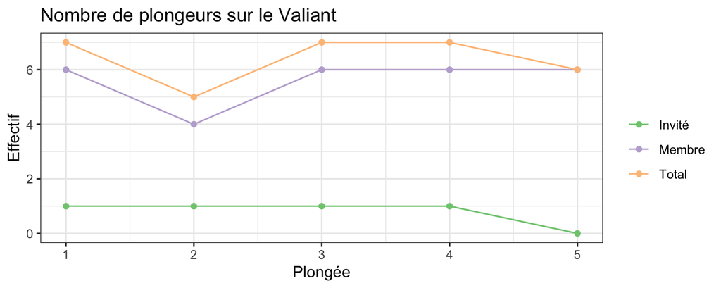

Figure 1: Plongeurs à bord du Valiant lors de chaque plongée

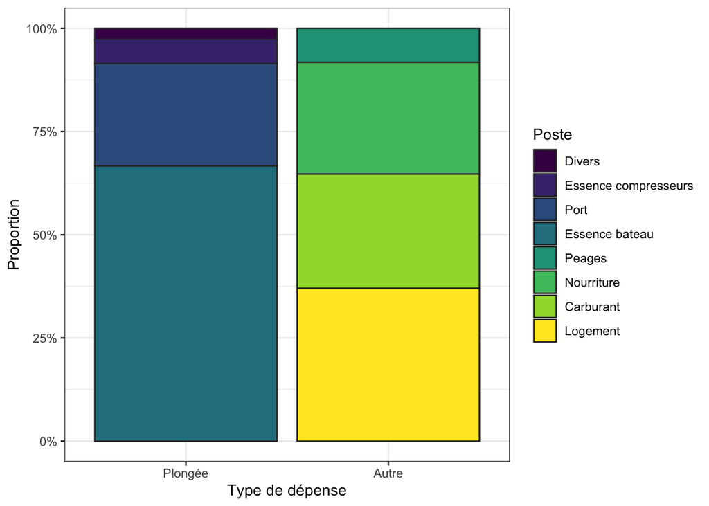

Figure 2: Proportion des dépenses par poste, pour la plongée et le reste

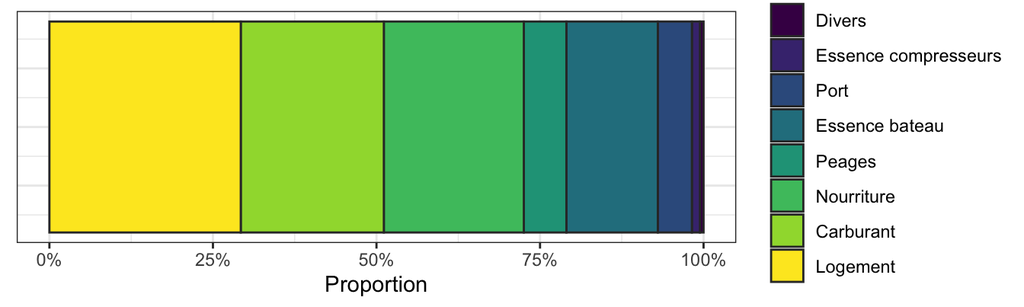

Figure 3: Proportion des dépenses de la sortie, tous postes confondus